# Data Wrangling Process

The following steps were taken to perform this analysis in project. This processes would be futher explained below

- Importing
- Data Gathering
- Data Accessing
- Data Cleaning
- Storing Cleaned Data
- Exploratory Data Analysis
- Conclusion

### Importing

The first step taken was to import the necessary python libraries used in this project.

### Data Gathering

The first dataset `twitter-archive-enhanced.csv` was given to me by the instructors at Udacity which I downloaded to my local desktop and was extracted manually using **pd.read_csv** and was saved as `twitter_achived`.

The secong dataset `image-predictions.tsv`was also given to me by Udacity instructors and was specifically instructed to download the file programmatically by using a python library called **request** which was done and I saved the file as `image_prediction`.

The third dataset to be gathered or extracted is by using the twiiter API, which required me to apply for twitter developers account. I got my twitter API keys from the twitter developer account .This dataset is be extracted using another python library called **tweepy**. The data was extracted by querying the twitter API and saved into a JSON file which was then turned into a dataframe. This dataframe was then accessed.

### Data Accessing

I accessed the extracted data in 2 ways which are

- Visual Accessment: Displaying the extracted data by using the `head()`, `Tail()` functions and
- Programmatic Accessment: Using the `info()` function

After accessing, I was able to identify some quality and tidiness issues which will be listed in the data cleaning section with the possible solution done

### Data Cleaning

Firstly, I made a copy of each datasets. After merging and cleaning my dataset, I also made a copy of my merged dataset

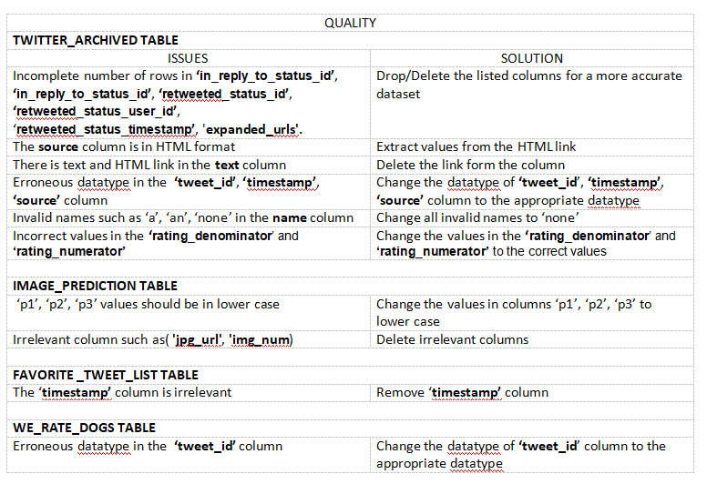

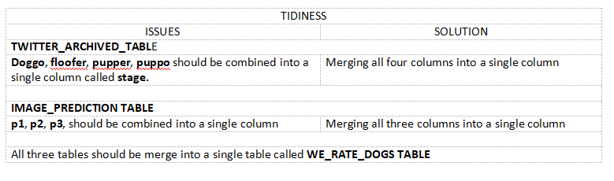

### Storing Data

After cleaning my data, I stored my data in a csv file which was later used for exploratory data analysis